# Lab 2: Cats vs Dogs

In this lab, you will train a convolutional neural network to classify an image into one of two classes: "cat" or "dog". The code for the neural networks you train will be written for you, and you are not (yet!) expected to understand all provided code. However, by the end of the lab, you should be able to:

1. Understand at a high level the training loop for a machine learning model.
2. Understand the distinction between training, validation, and test data.
3. The concepts of overfitting and underfitting.
4. Investigate how different hyperparameters, such as learning rate and batch size, affect the success of training.
5. Compare an ANN (aka Multi-Layer Perceptron) with a CNN.

### What to submit

Submit a PDF file containing all your code, outputs, and write-up from parts 1-5. You can produce a PDF of your Google Colab file by going to **File > Print** and then save as PDF. The Colab instructions has more information.

**Do not submit any other files produced by your code.**

Include a link to your colab file in your submission.

Please use Google Colab to complete this assignment. If you want to use Jupyter Notebook, please complete the assignment and upload your Jupyter Notebook file to Google Colab for submission.

With Colab, you can export a PDF file using the menu option `File -> Print` and save as PDF file. **Adjust the scaling to ensure that the text is not cutoff at the margins.**

## Colab Link

Include a link to your colab file here

Colab Link: https://colab.research.google.com/drive/1imbjKAqX8SsUPfXE0UioBjAilef-8JUn?usp=sharing

```python
import numpy as np
import time
import torch
import torch.nn as nn
import torch.nn.functional as F
import torch.optim as optim
import torchvision
from torch.utils.data.sampler import SubsetRandomSampler
import torchvision.transforms as transforms
```

## Part 0. Helper Functions

We will be making use of the following helper functions. You will be asked to look at and possibly modify some of these, but you are not expected to understand all of them.

You should look at the function names and read the docstrings. If you are curious, come back and explore the code *after* making some progress on the lab.

```python
###############################################################################
# Data Loading

def get_relevant_indices(dataset, classes, target_classes):
    """ Return the indices for datapoints in the dataset that belongs to the
    desired target classes, a subset of all possible classes.

    Args:
        dataset: Dataset object
        classes: A list of strings denoting the name of each class
        target_classes: A list of strings denoting the name of desired classes
                        Should be a subset of the 'classes'
    Returns:
        indices: list of indices that have labels corresponding to one of the
                 target classes
    """
    indices = []
    for i in range(len(dataset)):
        # Check if the label is in the target classes
        label_index = dataset[i][1] # ex: 3
        label_class = classes[label_index] # ex: 'cat'
        if label_class in target_classes:
            indices.append(i)
    return indices

def get_data_loader(target_classes, batch_size):
    """ Loads images of cats and dogs, splits the data into training, validation
    and testing datasets. Returns data loaders for the three preprocessed datasets.

    Args:
        target_classes: A list of strings denoting the name of the desired
                        classes. Should be a subset of the argument 'classes'
        batch_size: A int representing the number of samples per batch

    Returns:
        train_loader: iterable training dataset organized according to batch size
        val_loader: iterable validation dataset organized according to batch size
        test_loader: iterable testing dataset organized according to batch size
        classes: A list of strings denoting the name of each class
    """

    classes = ('plane', 'car', 'bird', 'cat',
               'deer', 'dog', 'frog', 'horse', 'ship', 'truck')
    ########################################################################
    # The output of torchvision datasets are PILImage images of range [0, 1].
    # We transform them to Tensors of normalized range [-1, 1].
    transform = transforms.Compose(
        [transforms.ToTensor(),
         transforms.Normalize((0.5, 0.5, 0.5), (0.5, 0.5, 0.5))])
    # Load CIFAR10 training data
    trainset = torchvision.datasets.CIFAR10(root='./data', train=True,
                                            download=True, transform=transform)
    # Get the list of indices to sample from
    relevant_indices = get_relevant_indices(trainset, classes, target_classes)

    # Split into train and validation
    np.random.seed(1000) # Fixed numpy random seed for reproducible shuffling
    np.random.shuffle(relevant_indices)
    split = int(len(relevant_indices) * 0.8) #split at 80%

    # split into training and validation indices
    relevant_train_indices, relevant_val_indices = relevant_indices[:split], relevant_indices[split:]
    train_sampler = SubsetRandomSampler(relevant_train_indices)
    train_loader = torch.utils.data.DataLoader(trainset, batch_size=batch_size,
                                               num_workers=1, sampler=train_sampler)
    val_sampler = SubsetRandomSampler(relevant_val_indices)
    val_loader = torch.utils.data.DataLoader(trainset, batch_size=batch_size,
                                              num_workers=1, sampler=val_sampler)
    # Load CIFAR10 testing data
    testset = torchvision.datasets.CIFAR10(root='./data', train=False,
                                           download=True, transform=transform)
    # Get the list of indices to sample from
    relevant_test_indices = get_relevant_indices(testset, classes, target_classes)
    test_sampler = SubsetRandomSampler(relevant_test_indices)
    test_loader = torch.utils.data.DataLoader(testset, batch_size=batch_size,
                                             num_workers=1, sampler=test_sampler)
    return train_loader, val_loader, test_loader, classes

###############################################################################
# Training
def get_model_name(name, batch_size, learning_rate, epoch):
    """ Generate a name for the model consisting of all the hyperparameter values

    Args:
        config: Configuration object containing the hyperparameters
    Returns:
        path: A string with the hyperparameter name and value concatenated
    """
    path = "model_{0}_bs{1}_lr{2}_epoch{3}".format(name,
                                                   batch_size,
                                                   learning_rate,
                                                   epoch)
    return path

def normalize_label(labels):
    """
    Given a tensor containing 2 possible values, normalize this to 0/1

    Args:
        labels: a 1D tensor containing two possible scalar values
    Returns:
        A tensor normalize to 0/1 value
    """
    max_val = torch.max(labels)
    min_val = torch.min(labels)
    norm_labels = (labels - min_val)/(max_val - min_val)
    return norm_labels

def evaluate(net, loader, criterion):
    """ Evaluate the network on the validation set.

     Args:
         net: PyTorch neural network object
         loader: PyTorch data loader for the validation set
         criterion: The loss function
     Returns:
         err: A scalar for the avg classification error over the validation set
         loss: A scalar for the average loss function over the validation set
     """
    total_loss = 0.0
    total_err = 0.0
    total_epoch = 0
    for i, data in enumerate(loader, 0):
        inputs, labels = data
        labels = normalize_label(labels)  # Convert labels to 0/1
        outputs = net(inputs)
        loss = criterion(outputs, labels.float())
        corr = (outputs > 0.0).squeeze().long() != labels
        total_err += int(corr.sum())
        total_loss += loss.item()
        total_epoch += len(labels)
    err = float(total_err) / total_epoch
    loss = float(total_loss) / (i + 1)
    return err, loss

###############################################################################
# Training Curve
def plot_training_curve(path):
    """ Plots the training curve for a model run, given the csv files
    containing the train/validation error/loss.

    Args:
        path: The base path of the csv files produced during training
    """
    import matplotlib.pyplot as plt
    train_err = np.loadtxt("{}_train_err.csv".format(path))
    val_err = np.loadtxt("{}_val_err.csv".format(path))
    train_loss = np.loadtxt("{}_train_loss.csv".format(path))
    val_loss = np.loadtxt("{}_val_loss.csv".format(path))
    plt.title("Train vs Validation Error")
    n = len(train_err) # number of epochs
    plt.plot(range(1,n+1), train_err, label="Train")
    plt.plot(range(1,n+1), val_err, label="Validation")
    plt.xlabel("Epoch")
    plt.ylabel("Error")
    plt.legend(loc='best')
    plt.show()
    plt.title("Train vs Validation Loss")
    plt.plot(range(1,n+1), train_loss, label="Train")
    plt.plot(range(1,n+1), val_loss, label="Validation")
    plt.xlabel("Epoch")
    plt.ylabel("Loss")
    plt.legend(loc='best')
    plt.show()
```

## Part 1. Visualizing the Data [7 pt]

We will make use of some of the CIFAR-10 data set, which consists of colour images of size 32x32 pixels belonging to 10 categories. You can find out more about the dataset at https://www.cs.toronto.edu/~kriz/cifar.html

For this assignment, we will only be using the cat and dog categories. We have included code that automatically downloads the dataset the first time that the main script is run.

```python
# This will download the CIFAR-10 dataset to a folder called "data"
# the first time you run this code.
train_loader, val_loader, test_loader, classes = get_data_loader(
    target_classes=["cat", "dog"],
    batch_size=1) # One image per batch
```

```
Downloading https://www.cs.toronto.edu/~kriz/cifar-10-python.tar.gz to ./data/cifar-10-python.tar.gz
```

```
Extracting ./data/cifar-10-python.tar.gz to ./data
Files already downloaded and verified
```

### Part (a) -- 1 pt

Visualize some of the data by running the code below. Include the visualization in your writeup.

(You don't need to submit anything else.)

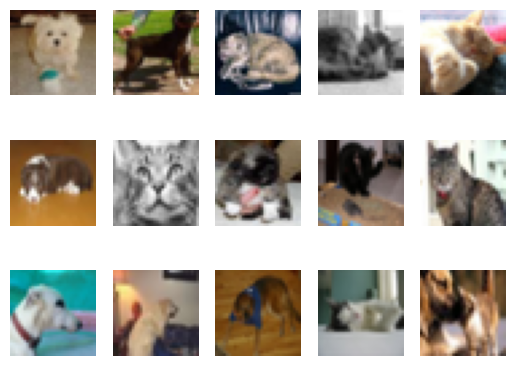

```python
import matplotlib.pyplot as plt

k = 0
for images, labels in train_loader:
    # since batch_size = 1, there is only 1 image in `images`
    image = images[0]
    # place the colour channel at the end, instead of at the beginning
    img = np.transpose(image, [1,2,0])
    # normalize pixel intensity values to [0, 1]
    img = img / 2 + 0.5
    plt.subplot(3, 5, k+1)
    plt.axis('off')
    plt.imshow(img)

    k += 1
    if k > 14:
        break
```

### Part (b) -- 3 pt

How many training examples do we have for the combined `cat` and `dog` classes? What about validation examples? What about test examples?

```python
print('There are',len(train_loader), 'training examples for the combined cat and dog classes.')
print('There are',len(val_loader), 'validation examples for the combined cat and dog classes.')
print('There are',len(test_loader), 'test examples for the combined cat and dog classes.')
```

```
There are 8000 training examples for the combined cat and dog classes.
There are 2000 validation examples for the combined cat and dog classes.
There are 2000 test examples for the combined cat and dog classes.
```

### Part (c) -- 3pt

Why do we need a validation set when training our model? What happens if we judge the performance of our models using the training set loss/error instead of the validation set loss/error?

## Part 2. Training [15 pt]

We define two neural networks, a `LargeNet` and `SmallNet`. We'll be training the networks in this section.

You won't understand fully what these networks are doing until the next few classes, and that's okay. For this assignment, please focus on learning how to train networks, and how hyperparameters affect training.

```python
class LargeNet(nn.Module):
    def __init__(self):
        super(LargeNet, self).__init__()
        self.name = "large"
        self.conv1 = nn.Conv2d(3, 5, 5)
        self.pool = nn.MaxPool2d(2, 2)
        self.conv2 = nn.Conv2d(5, 10, 5)
        self.fc1 = nn.Linear(10 * 5 * 5, 32)
        self.fc2 = nn.Linear(32, 1)

    def forward(self, x):
        x = self.pool(F.relu(self.conv1(x)))
        x = self.pool(F.relu(self.conv2(x)))
        x = x.view(-1, 10 * 5 * 5)
        x = F.relu(self.fc1(x))
        x = self.fc2(x)
        x = x.squeeze(1) # Flatten to [batch_size]
        return x
```

```python
class SmallNet(nn.Module):
    def __init__(self):
        super(SmallNet, self).__init__()
        self.name = "small"
        self.conv = nn.Conv2d(3, 5, 3)
        self.pool = nn.MaxPool2d(2, 2)
        self.fc = nn.Linear(5 * 7 * 7, 1)

    def forward(self, x):
        x = self.pool(F.relu(self.conv(x)))
        x = self.pool(x)
        x = x.view(-1, 5 * 7 * 7)
        x = self.fc(x)
        x = x.squeeze(1) # Flatten to [batch_size]
        return x
```

```python
small_net = SmallNet()
large_net = LargeNet()
```

### Part (a) -- 2pt

The methods `small_net.parameters()` and `large_net.parameters()` produces an iterator of all the trainable parameters of the network. These parameters are torch tensors containing many scalar values.

We haven't learned how how the parameters in these high-dimensional tensors will be used, but we should be able to count the number of parameters. Measuring the number of parameters in a network is one way of measuring the "size" of a network.

What is the total number of parameters in `small_net` and in `large_net`? (Hint: how many numbers are in each tensor?)

```python
for param in small_net.parameters():
    print(param.shape)
```

```
torch.Size([5, 3, 3, 3])
torch.Size([5])
torch.Size([1, 245])
torch.Size([1])
```

```python
small_total = 1
small_sum = 0

for param in small_net.parameters():
  for i in range(len(param.shape)):
    small_total *= param.shape[i]
  small_sum += small_total
  small_total = 1

print('There are', small_sum, 'parameters in small_net.')

large_total = 1
large_sum = 0

for param in large_net.parameters():
  for i in range(len(param.shape)):
    large_total *= param.shape[i]
  large_sum += large_total
  large_total = 1
print('There are', large_sum, 'parameters in small_net.')
```

```
There are 386 parameters in small_net.
There are 9705 parameters in small_net.
```

### The function train_net

The function `train_net` below takes an untrained neural network (like `small_net` and `large_net`) and several other parameters. You should be able to understand how this function works. The figure below shows the high level training loop for a machine learning model:

[figure not shown]

```python
def train_net(net, batch_size=64, learning_rate=0.01, num_epochs=30):
    ########################################################################
    # Train a classifier on cats vs dogs
    target_classes = ["cat", "dog"]
    ########################################################################
    # Fixed PyTorch random seed for reproducible result
    torch.manual_seed(1000)
    ########################################################################
    # Obtain the PyTorch data loader objects to load batches of the datasets
    train_loader, val_loader, test_loader, classes = get_data_loader(
            target_classes, batch_size)
    ########################################################################
    # Define the Loss function and optimizer
    # The loss function will be Binary Cross Entropy (BCE). In this case we
    # will use the BCEWithLogitsLoss which takes unnormalized output from
    # the neural network and scalar label.
    # Optimizer will be SGD with Momentum.
    criterion = nn.BCEWithLogitsLoss()
    optimizer = optim.SGD(net.parameters(), lr=learning_rate, momentum=0.9)
    ########################################################################
    # Set up some numpy arrays to store the training/test loss/erruracy
    train_err = np.zeros(num_epochs)
    train_loss = np.zeros(num_epochs)
    val_err = np.zeros(num_epochs)
    val_loss = np.zeros(num_epochs)
    ########################################################################
    # Train the network
    # Loop over the data iterator and sample a new batch of training data
    # Get the output from the network, and optimize our loss function.
    start_time = time.time()
    for epoch in range(num_epochs):  # loop over the dataset multiple times
        total_train_loss = 0.0
        total_train_err = 0.0
        total_epoch = 0
        for i, data in enumerate(train_loader, 0):
            # Get the inputs
            inputs, labels = data
            labels = normalize_label(labels) # Convert labels to 0/1
            # Zero the parameter gradients
            optimizer.zero_grad()
            # Forward pass, backward pass, and optimize
            outputs = net(inputs)
            loss = criterion(outputs, labels.float())
            loss.backward()
            optimizer.step()
            # Calculate the statistics
            corr = (outputs > 0.0).squeeze().long() != labels
            total_train_err += int(corr.sum())
            total_train_loss += loss.item()
            total_epoch += len(labels)
        train_err[epoch] = float(total_train_err) / total_epoch
        train_loss[epoch] = float(total_train_loss) / (i+1)
        val_err[epoch], val_loss[epoch] = evaluate(net, val_loader, criterion)
        print(("Epoch {}: Train err: {}, Train loss: {} |"+
               "Validation err: {}, Validation loss: {}").format(
                   epoch + 1,
                   train_err[epoch],
                   train_loss[epoch],
                   val_err[epoch],
                   val_loss[epoch]))
        # Save the current model (checkpoint) to a file
        model_path = get_model_name(net.name, batch_size, learning_rate, epoch)
        torch.save(net.state_dict(), model_path)
    print('Finished Training')
    end_time = time.time()
    elapsed_time = end_time - start_time
    print("Total time elapsed: {:.2f} seconds".format(elapsed_time))
    # Write the train/test loss/err into CSV file for plotting later
    epochs = np.arange(1, num_epochs + 1)
    np.savetxt("{}_train_err.csv".format(model_path), train_err)
    np.savetxt("{}_train_loss.csv".format(model_path), train_loss)
    np.savetxt("{}_val_err.csv".format(model_path), val_err)
    np.savetxt("{}_val_loss.csv".format(model_path), val_loss)
```

### Part (b) -- 1pt

The parameters to the function `train_net` are hyperparameters of our neural network. We made these hyperparameters easy to modify so that we can tune them later on.

What are the default values of the parameters `batch_size`, `learning_rate`, and `num_epochs`?

**Answer: The default values of batch_size is 64, learning_rate is 0.01, num_epochs is 30 as defined in the first line of the function.**

### Part (c) -- 3 pt

What files are written to disk when we call `train_net` with `small_net`, and train for 5 epochs? Provide a list of all the files written to disk, and what information the files contain.

```python
train_net(small_net, num_epochs = 5)
```

```
Downloading https://www.cs.toronto.edu/~kriz/cifar-10-python.tar.gz to ./data/cifar-10-python.tar.gz
```

```
Extracting ./data/cifar-10-python.tar.gz to ./data
Files already downloaded and verified
Epoch 1: Train err: 0.418625, Train loss: 0.6711218724250794 |Validation err: 0.372, Validation loss: 0.6551580280065536
Epoch 2: Train err: 0.35675, Train loss: 0.6371686363220215 |Validation err: 0.357, Validation loss: 0.6434999015182257
Epoch 3: Train err: 0.33725, Train loss: 0.6173642740249634 |Validation err: 0.3475, Validation loss: 0.6191077399998903
Epoch 4: Train err: 0.327, Train loss: 0.6018630278110504 |Validation err: 0.355, Validation loss: 0.6264621298760176
Epoch 5: Train err: 0.3135, Train loss: 0.5922581877708435 |Validation err: 0.32, Validation loss: 0.6174892988055944
Finished Training
Total time elapsed: 14.89 seconds
```

**Answer:**

**Models at 5 checkpoints are saved to 5 different files:**

1. **model_small_bs64_lr0.01_epoch0 saved at checkpoint: epoch 0**
2. **model_small_bs64_lr0.01_epoch1 saved at checkpoint: epoch 1**
3. **model_small_bs64_lr0.01_epoch2 saved at checkpoint: epoch 2**
4. **model_small_bs64_lr0.01_epoch3 saved at checkpoint: epoch 3**
5. **model_small_bs64_lr0.01_epoch4 saved at checkpoint: epoch 4**

**Also, the training error, training loss, validation error, and validation loss are saved to 4 different csv files for plotting.**

### Part (d) -- 2pt

Train both `small_net` and `large_net` using the function `train_net` and its default parameters. The function will write many files to disk, including a model checkpoint (saved values of model weights) at the end of each epoch.

If you are using Google Colab, you will need to mount Google Drive so that the files generated by `train_net` gets saved. We will be using these files in part (d). (See the Google Colab tutorial for more information about this.)

Report the total time elapsed when training each network. Which network took longer to train? Why?

```python
# Since the function writes files to disk, you will need to mount
# your Google Drive. If you are working on the lab locally, you
# can comment out this code.

from google.colab import drive
drive.mount('/content/gdrive')
```

```python
small_net = SmallNet()
large_net = LargeNet()

train_net(small_net)
train_net(large_net)

#Time for small_net: 135.90s
#Time for large_net: 151.60s
#Training for small_net takes less time because
#it has less parameter to tune than large_net
```

```
Files already downloaded and verified
Files already downloaded and verified
Epoch 1: Train err: 0.446375, Train loss: 0.6813716783523559 |Validation err: 0.3865, Validation loss: 0.6602997500449419
Epoch 2: Train err: 0.37325, Train loss: 0.6497629323005676 |Validation err: 0.3845, Validation loss: 0.6575995869934559
Epoch 3: Train err: 0.359875, Train loss: 0.6388978385925292 |Validation err: 0.3495, Validation loss: 0.6291275043040514
Epoch 4: Train err: 0.346375, Train loss: 0.6246587996482849 |Validation err: 0.356, Validation loss: 0.6221408396959305
Epoch 5: Train err: 0.334375, Train loss: 0.6153830280303955 |Validation err: 0.3275, Validation loss: 0.6188967823982239
Epoch 6: Train err: 0.318, Train loss: 0.6036732516288758 |Validation err: 0.339, Validation loss: 0.6094125052914023
Epoch 7: Train err: 0.315625, Train loss: 0.5944745948314667 |Validation err: 0.329, Validation loss: 0.5974238961935043
Epoch 8: Train err: 0.3085, Train loss: 0.5829453563690186 |Validation err: 0.3085, Validation loss: 0.5885121468454599
Epoch 9: Train err: 0.302, Train loss: 0.5805657277107239 |Validation err: 0.3115, Validation loss: 0.5845186104997993
Epoch 10: Train err: 0.29975, Train loss: 0.573062111377716 |Validation err: 0.309, Validation loss: 0.5785001656040549
Epoch 11: Train err: 0.287375, Train loss: 0.5632161114215851 |Validation err: 0.314, Validation loss: 0.5821095015853643
Epoch 12: Train err: 0.292125, Train loss: 0.5567435595989227 |Validation err: 0.3115, Validation loss: 0.5860895598307252
Epoch 13: Train err: 0.2885, Train loss: 0.5562505607604981 |Validation err: 0.306, Validation loss: 0.5769414035603404
Epoch 14: Train err: 0.280375, Train loss: 0.5473350758552551 |Validation err: 0.3115, Validation loss: 0.5721263345330954
Epoch 15: Train err: 0.285, Train loss: 0.5481121215820313 |Validation err: 0.305, Validation loss: 0.5623639700934291
Epoch 16: Train err: 0.2915, Train loss: 0.5539557900428772 |Validation err: 0.3135, Validation loss: 0.5774335078895092
Epoch 17: Train err: 0.28075, Train loss: 0.5475348830223083 |Validation err: 0.2995, Validation loss: 0.5680588381364942
Epoch 18: Train err: 0.279625, Train loss: 0.5440063354969025 |Validation err: 0.319, Validation loss: 0.576342330314219
Epoch 19: Train err: 0.27575, Train loss: 0.5402116534709931 |Validation err: 0.3295, Validation loss: 0.606647988781333
Epoch 20: Train err: 0.2715, Train loss: 0.5385935208797454 |Validation err: 0.298, Validation loss: 0.5778946885839105
Epoch 21: Train err: 0.27575, Train loss: 0.540246558189392 |Validation err: 0.302, Validation loss: 0.5672952607274055
Epoch 22: Train err: 0.279, Train loss: 0.5399930019378663 |Validation err: 0.2895, Validation loss: 0.5702174408361316
Epoch 23: Train err: 0.27325, Train loss: 0.5354620461463928 |Validation err: 0.303, Validation loss: 0.5667499387636781
Epoch 24: Train err: 0.27275, Train loss: 0.5359286315441132 |Validation err: 0.301, Validation loss: 0.5878297919407487
Epoch 25: Train err: 0.27325, Train loss: 0.5346703794002533 |Validation err: 0.297, Validation loss: 0.563475382514298
Epoch 26: Train err: 0.27025, Train loss: 0.5316284673213959 |Validation err: 0.2985, Validation loss: 0.5694020707160234
Epoch 27: Train err: 0.270375, Train loss: 0.5298305144309997 |Validation err: 0.301, Validation loss: 0.578824263997376
Epoch 28: Train err: 0.269625, Train loss: 0.5351403400897979 |Validation err: 0.3005, Validation loss: 0.5655373437330127
Epoch 29: Train err: 0.271875, Train loss: 0.5319398436546325 |Validation err: 0.2955, Validation loss: 0.5849009975790977
Epoch 30: Train err: 0.270875, Train loss: 0.5373601081371308 |Validation err: 0.3175, Validation loss: 0.5815494349226356
Finished Training
Total time elapsed: 135.90 seconds
Files already downloaded and verified
Files already downloaded and verified
Epoch 1: Train err: 0.454375, Train loss: 0.6898944606781006 |Validation err: 0.4205, Validation loss: 0.6793290264904499
Epoch 2: Train err: 0.418875, Train loss: 0.6788924961090088 |Validation err: 0.4215, Validation loss: 0.6790428329259157
Epoch 3: Train err: 0.40525, Train loss: 0.6685061388015747 |Validation err: 0.3905, Validation loss: 0.6528578028082848
Epoch 4: Train err: 0.379125, Train loss: 0.6512472186088561 |Validation err: 0.3935, Validation loss: 0.6531118471175432
```

[output cut: 13 more lines]

```
Epoch 18: Train err: 0.248125, Train loss: 0.4913763873577118 |Validation err: 0.296, Validation loss: 0.5609989166259766
Epoch 19: Train err: 0.23875, Train loss: 0.4821959674358368 |Validation err: 0.3045, Validation loss: 0.5786248967051506
Epoch 20: Train err: 0.23125, Train loss: 0.4757481541633606 |Validation err: 0.287, Validation loss: 0.580998913384974
Epoch 21: Train err: 0.22525, Train loss: 0.46251006150245666 |Validation err: 0.287, Validation loss: 0.5646722186356783
Epoch 22: Train err: 0.220375, Train loss: 0.4519791474342346 |Validation err: 0.2855, Validation loss: 0.5754687804728746
Epoch 23: Train err: 0.21375, Train loss: 0.44430874013900756 |Validation err: 0.288, Validation loss: 0.5742224156856537
Epoch 24: Train err: 0.207375, Train loss: 0.43036019349098203 |Validation err: 0.309, Validation loss: 0.6110728485509753
Epoch 25: Train err: 0.20175, Train loss: 0.4197188427448273 |Validation err: 0.2975, Validation loss: 0.5966625260189176
Epoch 26: Train err: 0.191125, Train loss: 0.4100140264034271 |Validation err: 0.2995, Validation loss: 0.6168392198160291
Epoch 27: Train err: 0.18725, Train loss: 0.4011841118335724 |Validation err: 0.3035, Validation loss: 0.6397394668310881
Epoch 28: Train err: 0.177375, Train loss: 0.38736681079864504 |Validation err: 0.3035, Validation loss: 0.614994109608233
Epoch 29: Train err: 0.170375, Train loss: 0.3770212644338608 |Validation err: 0.323, Validation loss: 0.7061460921540856
Epoch 30: Train err: 0.166125, Train loss: 0.3615760552883148 |Validation err: 0.3015, Validation loss: 0.6578065417706966
Finished Training
Total time elapsed: 151.60 seconds
```

### Part (e) - 2pt

Use the function `plot_training_curve` to display the trajectory of the training/validation error and the training/validation loss. You will need to use the function `get_model_name` to generate the argument to the `plot_training_curve` function.

Do this for both the small network and the large network. Include both plots in your writeup.

```
Small_net training curve:
```

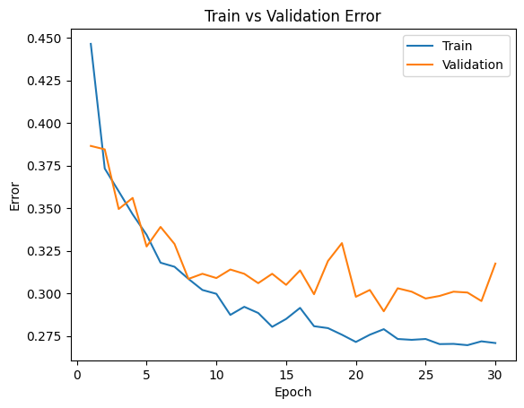

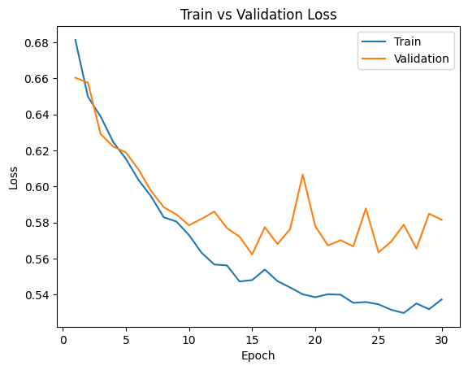

```
Large_net training curve:
```

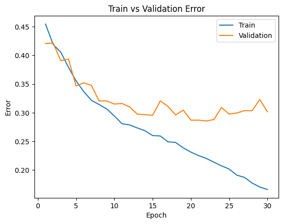

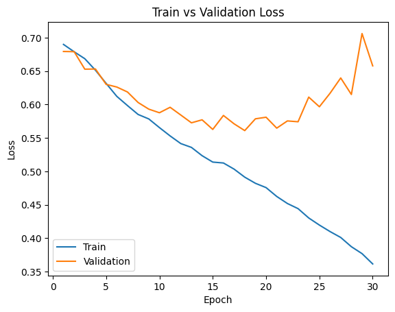

```python
#model_path = get_model_name("small", batch_size=??, learning_rate=??, epoch=29)
print("Small_net training curve:")
small_model_path = get_model_name("small", batch_size = 64,
                                  learning_rate = 0.01, epoch = 29)
plot_training_curve(small_model_path)
print("Large_net training curve:")
large_model_path = get_model_name("large", batch_size = 64,
                                  learning_rate = 0.01, epoch = 29)
plot_training_curve(large_model_path)
```

### Part (f) - 5pt

Describe what you notice about the training curve. How do the curves differ for `small_net` and `large_net`? Identify any occurences of underfitting and overfitting.

**Answer:**

**For the small_net model, the model exhibits underfitting at the beginning of the training. Both errors and losses for training and validation data are decreasing as the epoch increases. However, at the end the error and loss for the validation data becomes slightly flat, showing signs of increase, thus the small_net model may overfit if we train it for more epochs.**

**For the large_net model, the model also exhibits udnerfitting at the beginning of the training with errors and losses for both datasets decreasing. However, at around 15 epochs, the validation data's error and loss stop decreasing and start increase, showing signs of overfitting.**